## Data Load

```python
# Loading data table from csv files.
import pandas as pd
df_email_traffic = pd.read_csv('https://storage.googleapis.com/datalynn-datasets/interview-challenge/technology/Microsoft_Office365_Time_Series/EmailTraffic.csv')
```

# Question 1

**Data Manipulation & Cleaning**: Many users have reported that some emails have missing Importance scores. To fill these gaps, use statistical analysis to determine the best metric to replace these missing values. Considering the nature of our data, would it be best to replace missing values with the median or another statistical metric? Explain your reasoning.

## Solution:

### Hints:

1. **Explore the Distribution**
   - Before deciding on a metric to fill in missing values, it's important to understand the distribution of the "Importance" column. Visualize the distribution using a histogram and examine summary statistics like mean and median.
2. **Consider Outliers**
   - Since "Importance" is a continuous variable, consider the potential presence of outliers in the data. Think about which measure of central tendency (mean, median, etc.) is less affected by outliers and would provide a better representation of the typical value.
3. **Robustness of Medians**
   - Reflect on the robustness of the median as a measure of central tendency. Consider scenarios where outliers might significantly affect the mean but have less impact on the median. This will help you justify your choice of using the median to fill in missing "Importance" values.

```
count    4729.000000
mean        5.523070
std         2.495613
min         0.000000
25%         3.900000
50%         5.600000
75%         7.200000
max        14.100000
Name: Importance, dtype: float64
```

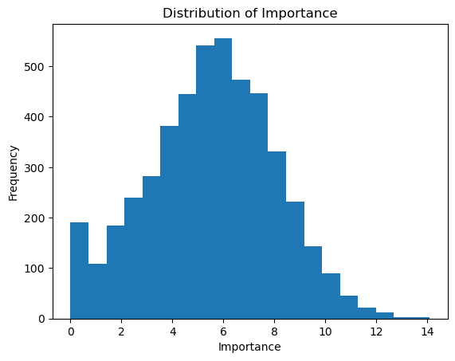

```
Median Importance: 5.6
Missing Importance values: 0
```

```python
import pandas as pd
import matplotlib.pyplot as plt

# Step 1: Explore the distribution of the Importance column
importance_summary = df_email_traffic['Importance'].describe()
print(importance_summary)

# Step 2: Visualize the distribution using a histogram
plt.hist(df_email_traffic['Importance'], bins=20)
plt.xlabel('Importance')
plt.ylabel('Frequency')
plt.title('Distribution of Importance')
plt.show()

# Step 3: Calculate the median of the Importance column
median_importance = df_email_traffic['Importance'].median()
print("Median Importance:", median_importance)

# Step 4: Fill missing Importance values with the calculated median
df_email_traffic['Importance'].fillna(median_importance, inplace=True)

# Step 5: Verify that there are no more missing values
missing_importance_count = df_email_traffic['Importance'].isnull().sum()
print("Missing Importance values:", missing_importance_count)

# Step 6: Save the updated DataFrame to a new CSV file if needed
# df_email_traffic.to_csv('updated_data.csv', index=False)
```

### Reasons for choosing median as the metric

In this case, the median is preferred over the mean because the Importance scores could have outliers that might disproportionately affect the mean. The median is a robust measure of central tendency that is less influenced by outliers, making it a better choice in this scenario.

# Question 2

**Probability and Statistics**: Given the dataset, we would like to understand how email traffic varies across different days of the week. What is the conditional probability that an email is of 'Work' type given that it's received on a 'Monday'? Also, derive insights on the distribution of the Importance scores for emails received on weekdays. Are they normally distributed?

## Solution:

### Hints:

1. **Conditional Probability Calculation**
   - To calculate the conditional probability that an email is of 'Work' type given that it's received on a 'Monday', you need to find the number of 'Work' emails received on Mondays and divide it by the total number of emails received on Mondays. Remember that conditional probability is calculated by dividing the number of favorable outcomes by the total number of possible outcomes.
2. **Data Filtering and Subsetting**
   - You'll need to filter the data based on specific conditions. Use pandas DataFrame filtering capabilities to extract the relevant data for calculating the conditional probability and for deriving insights about Importance scores on weekdays. The .loc[] or boolean indexing can be helpful for this.
3. **Distribution Analysis and Normality Test**
   - For the distribution of Importance scores received on weekdays, consider using visualization tools like histograms or probability plots to assess their distribution. To determine whether the Importance scores follow a normal distribution, use statistical tests like the Shapiro-Wilk test or Anderson-Darling test. These tests will give you insights into the shape of the distribution.

```
Conditional Probability of Work type email on Monday: 0.2966573816155989
Shapiro-Wilk Test - p-value: 7.906767688498073e-13
Importance scores for weekdays are not normally distributed (p <= 0.05)
```

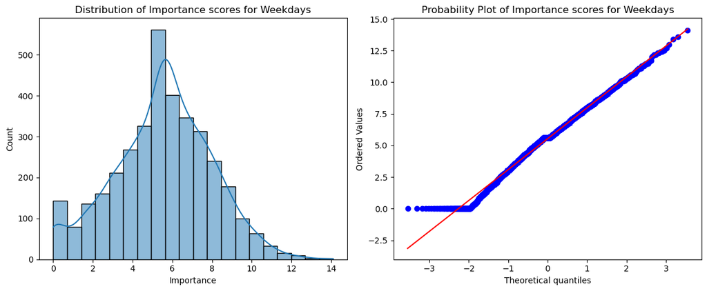

```python
import pandas as pd
import numpy as np
import matplotlib.pyplot as plt
import seaborn as sns
from scipy.stats import shapiro
from scipy.stats import probplot

# Step 2: Calculate conditional probability
work_on_monday = df_email_traffic[(df_email_traffic['EmailType'] == 'Work') & (df_email_traffic['Weekday'] == 'Monday')].shape[0]
total_on_monday = df_email_traffic[df_email_traffic['Weekday'] == 'Monday'].shape[0]
conditional_prob = work_on_monday / total_on_monday
print("Conditional Probability of Work type email on Monday:", conditional_prob)

# Step 3: Distribution of Importance scores for weekdays
weekday_importance = df_email_traffic[df_email_traffic['Weekday'].isin(['Monday', 'Tuesday', 'Wednesday', 'Thursday', 'Friday'])]['Importance']

# Step 4: Shapiro-Wilk test for normality
shapiro_stat, shapiro_p = shapiro(weekday_importance)
print("Shapiro-Wilk Test - p-value:", shapiro_p)
if shapiro_p > 0.05:
    print("Importance scores for weekdays are normally distributed (p > 0.05)")
else:
    print("Importance scores for weekdays are not normally distributed (p <= 0.05)")

# Step 5: Create a histogram and a probability plot
plt.figure(figsize=(12, 5))

plt.subplot(1, 2, 1)
sns.histplot(weekday_importance, bins=20, kde=True)
plt.title('Distribution of Importance scores for Weekdays')

plt.subplot(1, 2, 2)
probplot(weekday_importance, plot=plt)
plt.title('Probability Plot of Importance scores for Weekdays')

plt.tight_layout()
plt.show()
```

### Summary

Overall, this question helped you practice data manipulation, conditional probability calculations, distribution analysis, and statistical testing using Python and pandas.

# Question 3

**Machine Learning & Modeling**: Our primary goal is to predict the importance of an incoming email. Using the features from the `EmailTraffic` table, build a model to predict the `Importance` score of an email. Discuss potential issues like overfitting, especially considering the balance between different `EmailType` categories.

- Target Variable: Importance

## Solution:

### Hints:

1. **Understand the Problem**
   - Start by thoroughly understanding the problem statement and the data provided. Clarify any ambiguities in the task, and make sure you have a clear grasp of what's expected. Identify the target variable (Importance) and the features available in the dataset. This step is crucial as it forms the foundation for the entire modeling process.
2. **Focus on Data Preparation**
   - Data preprocessing is a critical step. You should be able to demonstrate your ability to handle different data types, handle missing values, and convert categorical features into a suitable format for modeling. Discuss how you plan to encode categorical variables, deal with datetime data, and potentially scale or normalize numerical features.
3. **Address Overfitting and Imbalance**
   - Overfitting and class imbalance are common challenges in machine learning. Be prepared to discuss strategies for addressing these issues. Explain how you would prevent overfitting by using techniques like train-test split, cross-validation, or regularization. Address the potential imbalance in the EmailType categories by mentioning techniques such as oversampling, undersampling, or using appropriate evaluation metrics.

```
Mean Squared Error: 3.463459234232079
```

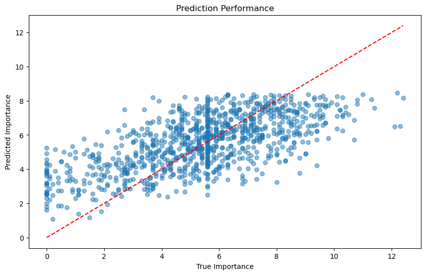

```
EmailType Distribution:
EmailType
Promotional    2022
Work           1538
Personal       1440
Name: count, dtype: int64
```

```python
import pandas as pd
from sklearn.model_selection import train_test_split
from sklearn.preprocessing import OneHotEncoder, StandardScaler
from sklearn.compose import ColumnTransformer
from sklearn.pipeline import Pipeline
from sklearn.linear_model import LinearRegression
from sklearn.metrics import mean_squared_error

# Step 1: Split the data into features (X) and target variable (y)
X = df_email_traffic.drop('Importance', axis=1)
y = df_email_traffic['Importance']

# Step 2: Split the data into training and testing sets
X_train, X_test, y_train, y_test = train_test_split(X, y, test_size=0.2, random_state=42)

# Step 3: Define which features are categorical and which are numerical
# categorical_features = ['UserID', 'EmailType', 'SenderDomain', 'Weekday', 'HourOfDay']
categorical_features = ['EmailType', 'SenderDomain', 'Weekday', 'HourOfDay']
numerical_features = ['ResponseTime', 'EmailSize', 'AttachmentNum']

# Step 4: Create a preprocessing pipeline for categorical features
categorical_transformer = Pipeline(steps=[
    ('onehot', OneHotEncoder(handle_unknown='ignore'))
])

# Step 5: Create a preprocessing pipeline for numerical features
numerical_transformer = Pipeline(steps=[
    ('scaler', StandardScaler())
])

# Step 6: Combine the preprocessing steps using ColumnTransformer
preprocessor = ColumnTransformer(
    transformers=[
        ('cat', categorical_transformer, categorical_features),
        ('num', numerical_transformer, numerical_features)
    ])

# Step 7: Create a complete pipeline with preprocessing and model
model = Pipeline(steps=[
    ('preprocessor', preprocessor),
    ('regressor', LinearRegression())  # You can replace LinearRegression with any other regression algorithm
])

# ... Rest of the code remains the same ...

# Step 8: Fit the model on the training data
model.fit(X_train, y_train)

# Step 9: Make predictions on the test data
y_pred = model.predict(X_test)

# Step 10: Evaluate the model using a suitable metric (e.g., Mean Squared Error)
mse = mean_squared_error(y_test, y_pred)
print(f"Mean Squared Error: {mse}")

# Step 11: plot the regression performance.
plt.figure(figsize=(10, 6))
plt.scatter(y_test, y_pred, alpha=0.5)
plt.plot([min(y_test), max(y_test)], [min(y_test), max(y_test)], color='red', linestyle='--')  # Diagonal line
plt.xlabel('True Importance')
plt.ylabel('Predicted Importance')
plt.title('Prediction Performance')
plt.show()

# Step 12: plot the regression performance. Addressing EmailType Imbalance
# If there is a significant class imbalance, consider using techniques like oversampling, undersampling,
# or using different evaluation metrics to handle the imbalance.
email_type_distribution = df_email_traffic["EmailType"].value_counts()
print("EmailType Distribution:")
print(email_type_distribution)
```

# Question 4

**Product Design & Analytics**: Imagine we're redesigning the notification system for Outlook. How would you use time series analysis on the `Timestamp` and `Importance` columns to design a model that intelligently predicts when a user is most likely to receive an important email in the next hour? This prediction would be instrumental in sending timely notifications to users, enhancing their experience.

## Solution:

### Hints:

1. **Data Preparation and Feature Engineering**
   - Understand the provided dataset's structure and columns. Make sure you identify the relevant features that might influence the likelihood of receiving an important email.
   - Focus on the `Timestamp` column as it will be crucial for time-based predictions. Consider extracting time-related features like the hour of the day, day of the week, and potentially other patterns.
   - Preprocess categorical features like `EmailType`, `SenderDomain`, and `Weekday` using techniques like one-hot encoding or label encoding to make them suitable for machine learning models.
2. **Temporal Aspect and Target Creation**
   - Remember that time series data has a temporal aspect, where the order of observations matters. Be cautious when splitting the data into training and testing sets to avoid data leakage.
   - Create a target variable that indicates whether an important email will arrive in the next hour. This might involve shifting the `Importance` column or deriving a suitable binary value that represents the occurrence of an important email in the subsequent hour.
3. **Model Selection and Interpretation**
   - Choose an appropriate machine learning model for classification, such as Random Forest, Logistic Regression, or Gradient Boosting. These models can capture complex relationships between features and predict binary outcomes.
   - Evaluate the model's performance using suitable metrics like accuracy or F1-score. Consider using techniques like cross-validation to assess how well the model generalizes to new data.
   - Interpret the model's results to gain insights into which features are most influential in predicting important emails. This understanding can guide feature selection and potential improvements to the model.

```python
import pandas as pd
from datetime import timedelta
from sklearn.model_selection import train_test_split
from sklearn.ensemble import RandomForestClassifier
from sklearn.metrics import accuracy_score

# Step 1: Data Preprocessing

# Convert Timestamp to datetime
df_email_traffic["Timestamp"] = pd.to_datetime(df_email_traffic["Timestamp"])

# Create a target variable for predicting whether an important email will arrive in the next hour. 9 here is a hyperparameter to specify which is important.
df_email_traffic["ImportantNextHour"] = df_email_traffic["Importance"].shift(-1) >= 9

# Drop rows with missing target values
df_email_traffic.dropna(subset=["ImportantNextHour"], inplace=True)

# Step 2: Feature Selection

# Select relevant features for the model
features = ["ResponseTime", "EmailSize", "AttachmentNum", "HourOfDay"]

# One-hot encode categorical variables (EmailType, SenderDomain, Weekday)
categorical_features = ["EmailType", "SenderDomain", "Weekday"]
df_email_traffic = pd.get_dummies(df_email_traffic, columns=categorical_features, drop_first=True)

# Step 3: Train-Test Split

X = df_email_traffic[features]
y = df_email_traffic["ImportantNextHour"]
X_train, X_test, y_train, y_test = train_test_split(X, y, test_size=0.2, random_state=42)

# Step 4: Model Training

model = RandomForestClassifier(n_estimators=100, random_state=42)
model.fit(X_train, y_train)

# Step 5: Model Evaluation

y_pred = model.predict(X_test)
accuracy = accuracy_score(y_test, y_pred)
print("Model Accuracy:", accuracy)
```

```
Model Accuracy: 0.931
```

### Summary

From this question, you learned how to utilize time series analysis and machine learning to predict when a user is likely to receive an important email in the next hour. You gained insights into data preprocessing, including datetime conversion and handling categorical variables. Additionally, you understood the importance of feature engineering, target creation, model selection, and interpretation for effective prediction in time-dependent scenarios.